# Prediction of restaurant ratings with Yelp dataset

### Predicting by matrix decomposition

To estimate $\sum_{j=1}^p b_{j,i} X_{i,k}$, we will consider the residuals $Y_{u,i}-\hat{\mu}-\hat{b}_i-\hat{b}_u$.

```r
##Filter train dataset so that we have users who rated more than 50 times and restaurants that got voted more than 100 times.
train_small <- train %>%
  filter(user_id %in% unique(test$user_id) & business_id %in% unique(test$business_id)) %>%
  group_by(business_id) %>%filter(n() >= 100) %>% ungroup %>%
  group_by(user_id) %>%filter(n() >= 50) %>%
  ungroup
train_small <- train_small %>%
  left_join(business_means, by = 'business_id') %>%
  left_join(user_means, by = 'user_id') %>%
  mutate(resids = star_individual - mu - b_i - b_u)

## The NAs are put into zeros.
Y <- train_small %>%
  select(user_id, business_id, resids) %>%
  spread(business_id, resids)
business_ids <- data.frame(colnames(Y) %>% setdiff('user_id'))
colnames(business_ids) <- 'business_id'
business_info <- train_small[!duplicated(train_small[,c('business_id')]),]

# create labels of business to plot on PCA
business_feature <- business_ids %>%
                    left_join(business_info, by = 'business_id') %>%
                    select(business_id, city, review_count, price, type, education_zip, population_zip)
user_ids <- Y[,1]
Y <- Y[,-1]
Y[is.na(Y)] <- 0
pca <- prcomp(Y, center=TRUE, scale=TRUE)
k <- 1
pred <- pca$x[,1:k] %*% t(pca$rotation[,1:k])
colnames(pred) <- colnames(Y)
interaction <-
    data.frame(user_id = user_ids, pred, check.names=FALSE) %>%
    tbl_df %>%
    gather(business_id, b_ui, -user_id) %>%
    mutate(business_id = as.character(business_id),
           user_id = as.character(user_id))
joined <- test %>%
  left_join(business_means, by='business_id') %>%
  left_join(user_means, by='user_id') %>%
  left_join(interaction, by=c('business_id','user_id')) %>%
  replace_na(list(b_i=0, b_u=0, b_ui=0))

predicted_ratings <- mu + joined$b_i + joined$b_u + joined$b_ui
matrix_decomp_model_rmse <- RMSE(predicted_ratings, test$star_individual)
matrix_decomp_model_rmse
```

```
## [1] 1.173552
```

Summarize the RMSE

```r
rmse_results <- data_frame(method = "Just the average", RMSE = naive_rmse)

rmse_results <- bind_rows(rmse_results,
                          data_frame(method="Restaurants Effect Model Lambda=4",
                                     RMSE = model1_reg_rmse))

rmse_results <- bind_rows(rmse_results,
                          data_frame(method="Restaurants and User Effect Model Alpha=7",
                                     RMSE = model2_reg_rmse))

rmse_results <- bind_rows(rmse_results,
                          data_frame(method="Matrix Decomposition",
                                     RMSE = matrix_decomp_model_rmse))
options(digits = 4)
rmse_results %>% kable
```

| method | RMSE |
| --- | --- |
| Just the average | 1.287 |
| Restaurants Effect Model Lambda=4 | 1.198 |
| Restaurants and User Effect Model Alpha=7 | 1.173 |
| Matrix Decomposition | 1.174 |

One way to explain this inefficiency is because restaurants rated at Yelp are not that accessible to users. Certain users and restuarants of the same geographical location are grouped together. When it comes to the user-restaurant matrix, most residual values are along the diagonal, and there are a lot zeros in the rest elements.

### Principal Component Analysis (PCA) for data visualisation

Principal component analysis (PCA) is a technique used to emphasize variation and bring out strong patterns in a dataset. Here, we want to use PCA visualize potential pattern of the variables.

#### All cities

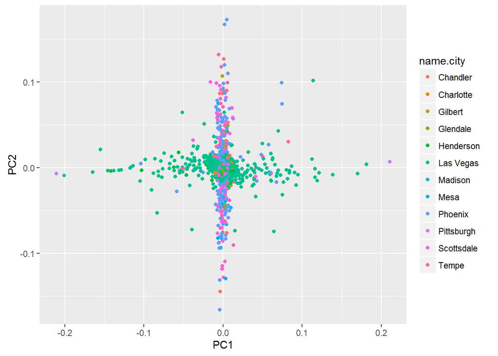

```r
tmp <- data.frame(pca$rotation, name = business_feature)
tmp %>%  ggplot(aes(PC1, PC2, color = name.city)) + geom_point()
```

The PC1-PC2 plot shows an interesting phenomenon: there seems to be one variable (PC1) that explains most of the variabilities among restaurants in Las Vegas, while restaurants in other cities are almost insensitive to this variable.On the other hand, PC2 explains most variances of those other restaurants, which is not the case in Las Vegas. Here we restricted our PCA analysis to Las Vegas.

#### Only Las Vegas

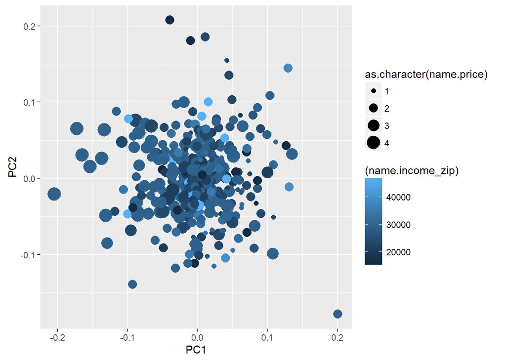

```r
combine_LV <- combine %>%filter(city == 'Las Vegas')

size = round(0.1*NROW(combine_LV))
test_LV <- sample_n(combine_LV, size = size, replace = FALSE)
train_LV <- setdiff(combine_LV, test)

train_small_LV <- train_LV %>%
  filter(user_id %in% unique(test_LV$user_id) & business_id %in% unique(test_LV$business_id)) %>% group_by(business_id) %>%
  filter(n() >= 120) %>% ungroup %>% group_by(user_id) %>%
  filter(n() >= 25) %>% ungroup

mu_LV <- mean(train_LV$star_individual)
business_means <- train_LV %>%
  group_by(business_id) %>%
  summarize(b_i = sum(star_individual-mu_LV)/(n()+lmd))
joined_LV <- test_LV %>%
  left_join(business_means, by = 'business_id') %>%
  replace_na(list(b_i = 0))
user_means <- train_LV %>%
  left_join(business_means, by = 'business_id') %>%
  group_by(user_id) %>%
  summarize(b_u = sum(star_individual - mu_LV - b_i)/(n()+a))
 joined_LV <- test_LV %>%
  left_join(business_means, by='business_id') %>%
  left_join(user_means, by='user_id') %>%
  replace_na(list(b_i=0, b_u=0))
train_small_LV <- train_small_LV %>%
  left_join(business_means, by = 'business_id') %>%
  left_join(user_means, by = 'user_id') %>%
  mutate(resids = star_individual - mu_LV - b_i - b_u)

Y_LV <- train_small_LV %>%
  select(user_id, business_id, resids) %>%
  spread(business_id, resids)

business_ids <- data.frame(colnames(Y_LV) %>% setdiff('user_id'))
colnames(business_ids) <- 'business_id'
business_info <- train_small_LV[!duplicated(train_small_LV[,c('business_id')]),]

# create labels of business to plot on PCA
business_feature <- business_ids %>%
                    left_join(business_info, by = 'business_id') %>%
                    select(business_id, city, review_count, price, type, education_zip, population_zip, zip, stars, noise, parking, income_zip, popdensity_zip)
user_ids <- Y_LV[,1]
Y_LV <- Y_LV[,-1]
Y_LV[is.na(Y_LV)] <- 0

pca_LV <- prcomp(Y_LV, center=TRUE, scale=TRUE)
tmp_LV <- data.frame(pca_LV$rotation, name = business_feature)
tmp_LV %>%  ggplot(aes(PC1, PC2, color =(name.income_zip))) + geom_point(aes(size = as.character(name.price)))
```

From the PC1-PC2 we can see some rating preference related with local income and price of restaurants: high price (3-4 dollar signs) restaurants in medium income area tend to get lower ratings, while restaurants with reasonable price (1-2 dollar signs) receive higher ratings.Also, most restaurants have price of 2-3 dollar sign, and they are less affected by local income.

We tried other PC1-PC2 plots with different labels and colors. However, we could not see any significant pattern.

## CONCLUSION

#### Restaurants ratings analysis

- From variable selection methods, we could see that generally, features of restaurants such as, but not limited to, price, parking and noise rather than exogenous factors such as demographic characteristics of the region where restaurants locate were significant predictors of ratings. In addition, we also found that the types of food was also strongly associated with ratings. This results might show that users’ preference for types of food is strongly correlated with their decision to chose restaurants and ratings.
- We also found that the model from Random Forest had the lowest RMSE. Otherwise, model performance was similar for other methods based on RMSE. Although RMSE values for stepwise and Lasso for a restricted dataset without Las Vegas were lower than that of the whole dataset, the differences were not big and they are higher than the RMSE of Random Forest. The comparativley better performance of Random Forest might be due to structural risk in our dataset such as outliers since other methods might not perform well because of those outliers.

#### Individual ratings analysis

- Lasso / Multinomial logistic regression performe better for predicting individual ratings than other methods in our dataset. However, all accurancies of the prediction is lower than 50%, which is not ideal.
- From the vaiable importance of the random forest, we see that individuals who always give postive words in reviews tends to give higher ratings. Demographic characteristic are also have impact on the individual ratings.

Low accuracies throughout all our predictions might not be explained easily. One possible reason could be the doubtful representativeness of the proxy for the quality of food and service. As we metioned above, sentiment of review text is subjective, and thus, it may be affected by many factors, not only users’ preference and weather, but also by their personality (harsher or generous) and personal events which can affect on their mood. Since Yelp uses an overall rating system, we cannot figure it out on what the overall rating of a user is actully based. Therefore, for a better prediction of ratings and an improved recommendation for specific users, Yelp may use a specified rating system instead of the current overall rating system. For example, if Yelp’s rating system includes several items to be evaluated by users such as quality of food, service and atmosphere, Yelp uesrs may get more clear ideas about restaurants.